# Data 609 - Module2

Amit Kapoor

9/10/2021

# Ex. 1

Show $x^{2} + exp(x) + 2 x^{4} + 1$ is convex.

**Solution:**

A function is considered convex if $f( \alpha x + \beta y) \leq \alpha f(x) + \beta f(y)$, $\forall x,y \in \Omega$, $\alpha \ge 0, \beta \ge 0$, $\alpha + \beta = 1$

$(\alpha x + \beta y)^{2} + exp(\alpha x + \beta y) + 2 (\alpha x + \beta y)^{4} + 1 \leq \alpha (x^{2} + exp(x) + 2 x^{4} + 1) + \beta (y^{2} + exp(y) + 2 y^{4} + 1)$

$(\alpha^{2} x^{2} + \beta^{2} y^{2} + 2 \alpha \beta x y ) + exp(\alpha x + \beta y) + 2 (\alpha x + \beta y)^{4} + 1 \leq \alpha x^{2} + \alpha exp(x) + 2 \alpha x^{4} + \alpha + \beta y^{2} + \beta exp(y) + 2 \beta y^{4} + \beta$

Using $\alpha + \beta = 1$ we rewrite as

$(\alpha^{2} x^{2} + \beta^{2} y^{2} + 2 \alpha \beta x y ) + exp(\alpha x + \beta y) + 2 (\alpha x + \beta y)^{4} \leq \alpha x^{2} + \alpha exp(x) + 2 \alpha x^{4} + \beta y^{2} + \beta exp(y) + 2 \beta y^{4}$

$2 \alpha x^{4} + \alpha x^{2} + \alpha exp(x) + 2 \beta y^{4} + \beta y^{2} + \beta exp(y) - (\alpha x + \beta y)^{2} - exp(\alpha x - \beta y) - 2 (\alpha x + \beta y)^{4} \geq 0$

The inequality is always true and hence $x^{2} + exp(x) + 2 x^{4} + 1$ is convex.

# Ex. 2

Show that the mean of the exponential distribution

$p(x) = \begin{cases} \lambda e^{- \lambda x}, & x \geq 0 ( \lambda > 0),\\0, & x < 0\end{cases}$

is $\mu = \frac{1}{ \lambda }$ and its variance is $\sigma ^{2} = \frac{1}{ \lambda ^{2} }$.

**Solution:**

To find the mean we know that $\mu = E[X] =\int xp(x)dx$

$\mu = \int_{-\infty}^0 x*0dx + \int_0^ \infty x \lambda e^{- \lambda x} dx$

Using integration by parts $\int u v dx = u \int v dx - \int u' (\int v dx) dx$

replacing $u=x, v=\lambda e^{- \lambda x}$ we will have

$\mu =[-x e^{- \lambda x}]_0^ \infty + \int_0^ \infty e^{- \lambda x} dx$

$\mu =[-x e^{- \lambda x}]_0^ \infty + [ -\frac{1}{ \lambda } e^{- \lambda x}]_0^ \infty$

$\mu = (0 - 0) + (0 + \frac{1}{ \lambda })$ = $\frac{1}{ \lambda }$

To find the variance of the given exponential distribution we know that $\sigma ^{2} = Var[X] = E[ X^{2}] - E[X] ^{2}$

$E[ X^{2}] = \int_0^ \infty x^{2} \lambda e^{- \lambda x}$ which could again be solved by using integration by parts

$E[ X^{2}] = [-x^{2} e^{- \lambda x}]_0^ \infty + \int_0^ \infty 2xe^{- \lambda x} dx$

$E[ X^{2}] = [-x^{2} e^{- \lambda x}]_0^ \infty +[- \frac{2}{ \lambda } x e^{- \lambda x} dx]_0^ \infty + \frac{2}{ \lambda } \int_0^ \infty e^{- \lambda x} dx$

using integration by parts again

$E[ X^{2}] = [-x^{2} e^{- \lambda x}]_0^ \infty +[- \frac{2}{ \lambda } x e^{- \lambda x} dx]_0^ \infty + \frac{2}{ \lambda } [- \frac{1}{ \lambda } x e^{- \lambda x} dx]_0^ \infty$

$(\frac{2}{ \lambda })( \frac{1}{ \lambda })$ = $\frac{2}{ \lambda ^{2}}$

$E[ X^{2}] - E[X] ^{2} = \frac{2}{\lambda ^{2}} - (\frac{1}{ \lambda }) ^{2} = \frac{2}{\lambda ^{2}} - \frac{1}{\lambda ^{2}} = \frac{1}{ \lambda ^{2}}$

# Ex. 3

It is estimated that there is a typo in every 250 data entries in a database, assuming the number of typos can obey the Poisson distribution. For a given 1000 data entries, what is the probability of exactly 4 typos? What is the probability of no typo at all? Use R to draw 1000 samples with $\lambda = 4$ and show their histogram.

**Solution:**

**what is the probability of exactly 4 typos?**

```r
lambda <- 1000 * (1/250)
x <- 4 # 4 typos
p_four_typo <- (lambda ^ x * exp(-lambda)) / factorial(x)
p_four_typo
```

```
## [1] 0.1953668
```

The probability of exactly 4 typos is 19.54%.

**What is the probability of no typo at all?**

```r
lambda <- 4
x <- 0 # no typo
p_zero_typo <- (lambda ^ x * exp(-lambda)) / factorial(x)
p_zero_typo
```

```
## [1] 0.01831564
```

The probability of no typos at all is 1.83%.

Now let’s confirm our results above using built in R function.

```r
# probability of exactly 4 typos
p1 <- dpois(4, lambda = 4)
p1
```

```
## [1] 0.1953668
```

```r
# probability of no typo
q2 <- dpois(0, lambda = 4)
q2
```

```
## [1] 0.01831564
```

**Use R to draw 1000 samples with $\lambda = 4$ and show their histogram.**

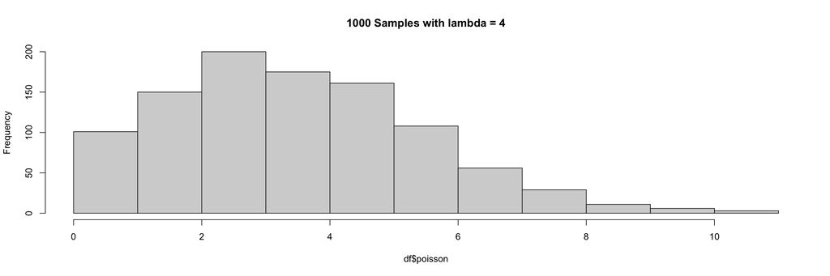

```r
events = 1:1000
lambda = 4
poisson <- rpois(1000, lambda)
df <- data.frame(events, poisson)

hist(df$poisson, main = "1000 Samples with lambda = 4")
```